# Q2 - Cell-type-specific differential expression

PsychAD - Shared and distinct transcriptional signatures in SCZ and BD

Author

Mariam H.

```r
suppressPackageStartupMessages({
  library(Matrix)
  library(ggplot2)
  library(knitr)
  library(here)})

source(here::here("02_CODE", "scripts", "utils_figures.R"))

col_main <- unname(project_colours$Q2["dark"])
col_groups <- c(Control = "grey60", col_disease[c("SCZ", "BD")])
```

**NoteHow to read this notebook**

This notebook documents the differential expression analysis (Q2) of the PsychAD HBCC cohort.

Each section briefly explains the objectives, followed by the R code and its outputs with an interpretation based on obtained results.

Methodological decisions and limitations are discussed where relevant.

The preprocessing and pseudobulk aggregation were performed in the upstream notebooks / scripts. This notebook reuses their saved outputs without repeating these steps.

Cited references are listed at the end.

# 1 Overview

## 1.1 Research question and objectives

*Central research question : Do schizophrenia and bipolar disorder share cell-type specific transcriptional alterations in the human prefrontal cortex, and could these changes affect neuronal-glial signaling and ageing-associated transcriptional profiles ?*

*Q2 research question : Do schizophrenia and bipolar disorder share cell-type-specific transcriptional alterations in the human prefrontal cortex ?*

**Objective of Q2 :** To identify and compare disease-associated differential gene expression within individual neuronal and non neuronal cell subclasses and to investigate the degree of transcriptional convergence and divergence between SCZ and BD.

The analysis is divided into two complementary notebooks:

- **Q2_1 - Pseudobulk differential expression :** identification of differentially expressed genes using donor-level pseudobulk DESeq2 models.
- **Q2_2 - Shared and distinct signatures :** gene-level comparison of SCZ- and BD-associated transcriptional alterations using the results of Q2_1.

The present notebook focuses on the first component: differential expression modelling, quality assessment and sensitivity analyses.

## 1.2 Links with previous analyses

Schizophrenia (SCZ) and bipolar disorder (BD) are complex psychiatric conditions with partially overlapping genetic susceptibility and molecular features. However, their transcriptional alterations may differ across neuronal, glial and vascular-associated populations [1].

The previous notebooks established the biological and analytical framework for investigating these differences.

**Preprocessing - Cohort selection and pseudobulk aggregation.** The PsychAD HBCC cohort was restricted to 224 eligible adult donors (121 controls, 49 SCZ and 54 BD). Raw RNA counts were aggregated for each donor and annotated cell subclass to create pseudobulk expression profiles.

This aggregation preserves donors as biological replicates and avoids treating individual nuclei from the same person as independent observations [2].

**Q1 - Cell-type composition.** The composition analysis identified a lower relative abundance of microglia in both SCZ and BD, with stronger evidence of robustness in SCZ following ancestry-restricted analyses. A reduction in oligodendrocyte proportions was also detected in BD, although this finding appeared more sensitive to potential confounding.

These results suggest that some cellular populations may be differentially represented across diagnoses. However, **changes in cellular abundance do not necessarily imply corresponding changes in gene expression**, and transcriptional alterations may occur even when cell proportions remain unchanged.

Q2 provides a complementary perspective by investigating molecular differences **within each cell subclass**, rather than differences in the relative abundance of those populations.

This distinction is essential for separating cell-composition effects from cell-subclass-specific transcriptional signatures.

## 1.3 Why donor-level pseudobulk differential expression ?

Single-nucleus RNA sequencing provides expression profiles for thousands of nuclei across multiple cellular populations.

However, nuclei originating from the same donor share biological and technical characteristics, including genetic background, age and sample preparation. Treating them as statistically independent replicates may lead to inflated significance and false discoveries [2].

To address this issue, gene counts are aggregated at the **donor x cell-subclass level**, generating one pseudobulk profile per donor and subclass.

Differential expression is then analysed using DESeq2, which models RNA sequencing counts through a negative binomial framework and estimates gene-specific dispersion [3,4].

This approach allows us to :

- Identify genes associated with SCZ relative to controls.
- Identify genes associated with BD relative to controls.
- Directly test transcriptional differences between SCZ and BD.
- Compare disease-associated changes across neuronal and non-neuronal subclasses.
- Generate complete gene-level statistics for downstream cross-disease and functional analyses.

The analysis includes age, sex and genetic ancestry as covariates to account for important sources of variation between donors.

## 1.4 Input data and analytical strategy

The main input is the pseudobulk count matrix generated during preprocessing from the PsychAD HBCC cohort.

| Input characteristic | Description |
| --- | --- |
| Cohort | 224 donors aged 20 years or older |
| Diagnostic groups | Control (121), SCZ (49), BD (54) |
| Cell populations | 27 annotated subclasses |
| Count matrix | 34,176 genes × 6,048 donor–subclass profiles |
| Expression values | Raw, non-negative integer counts |
| Metadata | Donor, subclass, nucleus count, diagnosis, age, sex and ancestry |

The matrix was generated using all available nuclei from the selected donors, unlike the smaller Seurat subsample used for visualization and Q4.

The pseudobulk object contains :

- `counts` : a sparse matrix of raw gene counts.
- `description` : metadata corresponding to each donor–subclass profile.

Before differential expression modelling, donor–subclass profiles are required to contain at least **20 nuclei**, and eligible subclasses must be represented by at least **10 donors in each diagnostic group**.

Genes with fewer than 10 total counts across the retained samples of a subclass are excluded before DESeq2 fitting.

Three diagnostic contrasts are analysed:

1. **SCZ versus Control**
2. **BD versus Control**
3. **SCZ versus BD**

Statistical significance is evaluated using an adjusted p-value threshold of **FDR < 0.05**, with DESeq2 independent filtering performed for each contrast.

## 1.5 Statistical considerations and sensitivity analyses

Several limitations must be considered when interpreting disease-associated expression differences.

**Genetic ancestry imbalance.** The distribution of genetic ancestry differs considerably between the three diagnostic groups. In particular, BD donors are predominantly of European ancestry, while SCZ donors are predominantly of African ancestry. Genetic ancestry is therefore included as a covariate in the statistical model.

**Unequal donor representation.** The number of donors contributing to individual cell subclasses differs across groups, potentially affecting statistical power and the detection of significant genes.

**Unmeasured confounding.** Technical and clinical variables, including some post-mortem characteristics and treatment-related factors, are not available in the pseudobulk metadata used here.

**Multiple testing.** FDR correction is performed within each subclass–contrast comparison, rather than globally across all comparisons.

To assess the robustness of the primary findings, complementary sensitivity analyses are included:

- **Ancestry-restricted models :** comparison of selected diagnostic groups within major ancestry categories in astrocytes.
- **Age-threshold sensitivity :** repetition of the DESeq2 workflow after increasing the minimum donor age from 20 to 24 years.

These analyses evaluate the stability of the findings under alternative sample selections but do not constitute independent validation.

## 1.6 Expected outputs and downstream integration

The primary DESeq2 results are saved in `03_RESULTS/Q2_differential_expression/`, including complete gene-level tables, significant DEG lists, Wald-statistic rankings and model summaries.

A consolidated file, `01_DATA/processed/de_results_all.csv`, is generated for downstream Q3 analyses.

The results also provide the foundation for the second Q2 notebook, `03_Q2_2_shared_specific_signatures.qmd`, which investigates shared and distinct transcriptional signatures between SCZ and BD.

**Q3 - Functional enrichment :** complete gene-level statistics are used to investigate biological pathways through ORA and GSEA.

**Q4 - Cell–cell communication :** disease-associated expression patterns will help contextualize inferred ligand–receptor interactions and neuronal-glial signaling networks.

**Q5 - Transcriptomic ageing :** disease-associated expression changes can be examined in relation to ageing-associated transcriptional programs.

## 1.7 Analysis plan

| Step | Analysis | Main output |
| --- | --- | --- |
| 1 | Input data validation | Count matrix and metadata integrity |
| 2 | Sample eligibility and subclass selection | Eligible donor–subclass profiles |
| 3 | Covariate balance and potential confounding | Diagnostic-group characteristics |
| 4 | Statistical design and identifiability | Adjusted DESeq2 model |
| 5 | Astrocyte pilot differential expression | Three diagnostic contrasts |
| 6 | Statistical quality assessment | Normalization, PCA and dispersion |
| 7 | Differential expression across subclasses | Complete gene-level results |
| 8 | Ancestry-restricted sensitivity analyses | Robustness in selected subgroups |
| 9 | Age-threshold sensitivity analysis | Comparison between age thresholds |
| 10 | Reproducibility and downstream outputs | Q2 results and Q3 export |

The next notebook will extend this analysis by comparing effect sizes, shared significant genes and direct diagnostic differences between SCZ and BD.

# 2 Input data validation

## 2.1 Load pseudobulk data

```r
input_file <- here::here("01_DATA", "processed", "pseudobulk_HBCC_224donors.rds")
pb <- readRDS(input_file)
counts <- pb$counts
meta <- pb$description
```

## 2.2 Validate matrix structure and metadata alignments

```r
required_columns <- c("donor", "subclass", "column", "n_nuclei", "group", "age", "sex", "ancestry")

stopifnot(inherits(counts, "dgCMatrix"), is.data.frame(meta), all(required_columns %in% names(meta)), ncol(counts) == nrow(meta), identical(colnames(counts), meta$column), !anyDuplicated(meta$column), !anyNA(meta[, c("donor", "subclass", "column", "n_nuclei", "group")]), all(meta$n_nuclei >= 0), all(meta$group %in% c("Control", "SCZ", "BD")))

#DESeq2 requires non-negative integer counts
stopifnot(all(is.finite(counts@x)), all(counts@x >= 0), all(counts@x == round(counts@x)))

#Empty donor x subclasses combinations must contain zero counts
empty_profiles <- meta$n_nuclei == 0
if (any(empty_profiles)){stopifnot(all(Matrix::colSums(counts[, empty_profiles, drop = FALSE]) == 0))}
```

## 2.3 Verify donor-level consistency

```r
donor_info <- unique(meta[, c("donor", "group", "age", "sex", "ancestry")])
if (anyDuplicated(donor_info$donor)){stop("Inconsistent metadata detected for one or more donors")}
stopifnot(nrow(donor_info) == 224)

group_sizes <- as.data.frame(table(donor_info$group))
colnames(group_sizes) <- c("Diagnosis", "Donors")

knitr::kable(group_sizes, caption = "Donor distribution in input cohort")
```

Donor distribution in input cohort

| Diagnosis | Donors |
| --- | --- |
| BD | 54 |
| Control | 121 |
| SCZ | 49 |

## 2.4 Input dataset summary

```r
dataset_summary <- data.frame(Characteristic = c("Selected donors", "Cell subclasses", "Genes", "Donor-subclass profiles", "Profiles without nuclei"), Value = c(nrow(donor_info), length(unique(meta$subclass)), nrow(counts), ncol(counts), sum(empty_profiles)))

knitr::kable(dataset_summary, caption = "Summary of the pseudobulk input dataset")
```

Summary of the pseudobulk input dataset

| Characteristic | Value |
| --- | --- |
| Selected donors | 224 |
| Cell subclasses | 27 |
| Genes | 34176 |
| Donor-subclass profiles | 6048 |
| Profiles without nuclei | 444 |

**TipInterpretation**

The input retains all donor-subclass combinations, including populations that were absent in some donors. The 444 zero-nucleus profiles are expected from the prepocessed strategy and must not be treated as valid biological samples for the analysis.

NB : No differential expression test is performed at this stage. Sample eligibility, donor representation and covariate balance will therefore be assessed before model fitting.

# 3 Sample eligibility and subclass selection

**NotePrinciple**

Differential expression analysis requires sufficient nuclei to get instructive pseudobulk profiles and sufficient biological replicates in each diagnostic group.

As established during preprocessing (criterion E7), donor-subclass profiles containing at least **20 nuclei** were retained. A subclass is considered eligible for the primary analysis if there are at least **10 donors per diagnostic group** that satisfy this threashold.

These criteria were defined before differential expression testing and are applied across our three conditions : Control, SCZ and BD. Subclass eligibility is assessed independently of the cell-composition results from Q1 as transcriptional changes may occur without corresponding changes in cellular abundance.

## 3.1 Apply sample eligibility criteria

```r
nuclei_min <- 20
donors_min_per_group <- 10

#Retain pseudobulks with sufficient nuclei
meta_eligible <- meta[meta$n_nuclei >= nuclei_min, , drop = FALSE]

#Check each donor contributes only once per subclasses (no duplicate)
stopifnot(!anyDuplicated(meta_eligible[, c("donor", "subclass")]))

#Keep all subclasses (including those with no eligible profiles)
donor_counts <- with(meta_eligible, table(factor(subclass, levels = sort(unique(meta$subclass))), factor(group, levels = c("Control", "SCZ", "BD"))))

eligibility <- data.frame(Subclass = rownames(donor_counts), Control = as.integer(donor_counts[, "Control"]), SCZ = as.integer(donor_counts[, "SCZ"]), BD = as.integer(donor_counts[, "BD"]))

eligibility$Eligible <- apply(eligibility[, c("Control", "SCZ", "BD")], 1, min) >= donors_min_per_group

knitr::kable(eligibility, caption = "Eligible donors per subclass and diagnosis after minimum nucleus count filter")
```

Eligible donors per subclass and diagnosis after minimum nucleus count filter

| Subclass | Control | SCZ | BD | Eligible |
| --- | --- | --- | --- | --- |
| Adaptive | 10 | 1 | 3 | FALSE |
| Astro | 118 | 44 | 53 | TRUE |
| EN_L2_3_IT | 113 | 45 | 48 | TRUE |
| EN_L3_5_IT_1 | 95 | 39 | 40 | TRUE |
| EN_L3_5_IT_2 | 109 | 42 | 46 | TRUE |
| EN_L3_5_IT_3 | 106 | 39 | 45 | TRUE |
| EN_L5_6_NP | 83 | 27 | 35 | TRUE |
| EN_L5_ET | 0 | 0 | 0 | FALSE |
| EN_L6_CT | 86 | 31 | 35 | TRUE |
| EN_L6_IT_1 | 82 | 27 | 35 | TRUE |
| EN_L6_IT_2 | 55 | 19 | 26 | TRUE |
| EN_L6B | 74 | 25 | 33 | TRUE |
| Endo | 109 | 40 | 40 | TRUE |
| IN_ADARB2 | 96 | 37 | 38 | TRUE |
| IN_LAMP5_LHX6 | 90 | 29 | 40 | TRUE |
| IN_LAMP5_RELN | 103 | 38 | 46 | TRUE |
| IN_PVALB | 110 | 41 | 49 | TRUE |
| IN_PVALB_CHC | 96 | 34 | 42 | TRUE |
| IN_SST | 112 | 42 | 48 | TRUE |
| IN_VIP | 113 | 45 | 51 | TRUE |
| Micro | 112 | 38 | 46 | TRUE |
| Oligo | 121 | 46 | 52 | TRUE |
| OPC | 120 | 45 | 53 | TRUE |
| PC | 91 | 31 | 38 | TRUE |
| PVM | 22 | 3 | 6 | FALSE |
| SMC | 12 | 9 | 8 | FALSE |
| VLMC | 60 | 22 | 23 | TRUE |

**TipInterpretation**

After applying the minimum nucleus and donor-count criteria, **23 of the 27 cell subclasses remained eligible** for differential expression analysis.

Four subclasses (Adaptive, EN_L5_ET, PVM and SMC) were excluded due to insufficient representation across diagnostic groups.

The retained populations include neuronal, glial and vascular-associated subclasses, allowing cell-subclass-specific comparisons across a broad range of cortical cell populations.

## 3.2 Summary of eligible populations

```r
eligible_subclasses <- eligibility$Subclass[eligibility$Eligible]
eligibility_summary <- data.frame(Criterion = c("Initial pseudobulk profiles", "Profiles with >= 20 nuclei", "Initial subclasses", "Eligible subclasses", "Excluded subclasses"), Value = c(nrow(meta), nrow(meta_eligible), length(unique(meta$subclass)), length(eligible_subclasses), sum(!eligibility$Eligible)))

knitr::kable(eligibility_summary, caption = "Sample and subclass eligibility summary")
```

Sample and subclass eligibility summary

| Criterion | Value |
| --- | --- |
| Initial pseudobulk profiles | 6048 |
| Profiles with >= 20 nuclei | 4116 |
| Initial subclasses | 27 |
| Eligible subclasses | 23 |
| Excluded subclasses | 4 |

**TipInterpretation**

*Of the 6 048 initial donor-subclass profiles, 4 116 contained at least 20 nuclei.* Applying the additional requirement of at least 10 eligible donors per diagnostic group *retained 23 of the 27 annotated subclasses* for differential expression analysis.

Four subclasses (`Adaptive, EN_L5_ET, PVM and SMC`) did not meet those criteria and were therefore excluded from the primary analysis. Their exclusion reflects limited sample representation and not an absence of disease-related transcriptional alterations.

The retained populations include major neuronal and glial subclasses, enabling cell-subclass specific comparison across the three diagnosis groups. But, sample eligibility does not guarantee that covariate-adjusted models will be sufficiently supported. This will be assessed in the following section.

# 4 Covariate balance and potential confounding

**NotePrinciple**

The preprocessing analysis revealed major differences in genetic ancestry and age between the three diagnostic groups. These imbalances may confound the estimation of disease-associated transcriptional effects.

As each cell subclass retains a different subset of donors after nucleus-count filtering, covariate distributions must be reassessed within the populations selected for Q2. This step focuses on the following variables : **genetic ancestry, age and sex**.

## 4.1 Retained profiles and metadata completeness

```r
meta_q2 <- meta_eligible[meta_eligible$subclass %in% eligible_subclasses, , drop = FALSE]

#No missing covariates and duplicated donor-subclass profiles
stopifnot(!anyNA(meta_q2[, c("age", "sex", "ancestry")]), !anyDuplicated(meta_q2[, c("donor", "subclass")]), all(meta_q2$age >= 20))

cat("Profiles retained for Q2 :", nrow(meta_q2), "\n")
```

```
Profiles retained for Q2 : 4042
```

```r
cat("Cell subclasses :", length(unique(meta_q2$subclass)), "\n")
```

```
Cell subclasses : 23
```

```r
cat("Donors represented :", length(unique(meta_q2$donor)), "\n")
```

```
Donors represented : 224
```

**TipInterpretation**

After applying both eligibility criteria, *4 042 pseudobulk profiles from 23 subclasses remain available for Q2*. All 224 selected donors are represented in at least one retained subclass.

No missing values were detected for age, sex or genetic ancestry, and each donor contributes at most one profile per subclass. However, the number of donors differs between subclasses : diagnostic-group representation must therefore be considered separately for each differential expression model.

## 4.2 Genetic ancestry representation

The diagnostic groups show unequal genetic ancestry distributions, as previously described in preprocessing (Figure PP-F02). To assess the possible implications for Q2, ancestry counts are examined separately for each retained subclass.

```r
group_levels <- c("Control", "SCZ", "BD")
ancestry_counts <- xtabs(~ subclass + group + ancestry, data = meta_q2)
ancestry_balance <- data.frame(Subclass = eligible_subclasses,
                               Control_African = as.integer(ancestry_counts[eligible_subclasses, "Control", "African"]),
                               SCZ_African = as.integer(ancestry_counts[eligible_subclasses, "SCZ", "African"]),
                               BD_African = as.integer(ancestry_counts[eligible_subclasses, "BD", "African"]),
                               Control_European= as.integer(ancestry_counts[eligible_subclasses, "Control", "European"]),
                               SCZ_European = as.integer(ancestry_counts[eligible_subclasses, "SCZ", "European"]),
                               BD_European = as.integer(ancestry_counts[eligible_subclasses, "BD", "European"]))

knitr::kable(ancestry_balance, caption = "Donor counts by major genetic ancestry, diagnosis and eligible cell subclass")
```

Donor counts by major genetic ancestry, diagnosis and eligible cell subclass

| Subclass | Control_African | SCZ_African | BD_African | Control_European | SCZ_European | BD_European |
| --- | --- | --- | --- | --- | --- | --- |
| Astro | 68 | 29 | 4 | 42 | 11 | 44 |
| EN_L2_3_IT | 64 | 28 | 4 | 42 | 12 | 39 |
| EN_L3_5_IT_1 | 55 | 27 | 4 | 34 | 9 | 31 |
| EN_L3_5_IT_2 | 61 | 27 | 4 | 40 | 10 | 37 |
| EN_L3_5_IT_3 | 62 | 25 | 4 | 38 | 9 | 36 |
| EN_L5_6_NP | 46 | 15 | 2 | 32 | 8 | 29 |
| EN_L6_CT | 48 | 19 | 2 | 32 | 8 | 29 |
| EN_L6_IT_1 | 47 | 18 | 2 | 30 | 6 | 30 |
| EN_L6_IT_2 | 35 | 12 | 1 | 17 | 5 | 22 |
| EN_L6B | 43 | 17 | 2 | 26 | 6 | 28 |
| Endo | 61 | 26 | 3 | 42 | 10 | 33 |
| IN_ADARB2 | 53 | 23 | 4 | 37 | 10 | 30 |
| IN_LAMP5_LHX6 | 53 | 17 | 3 | 32 | 9 | 32 |
| IN_LAMP5_RELN | 60 | 26 | 4 | 37 | 9 | 38 |
| IN_PVALB | 63 | 26 | 4 | 41 | 10 | 40 |
| IN_PVALB_CHC | 56 | 23 | 4 | 34 | 7 | 33 |
| IN_SST | 63 | 26 | 3 | 42 | 11 | 40 |
| IN_VIP | 63 | 28 | 4 | 43 | 12 | 42 |
| Micro | 64 | 22 | 4 | 41 | 11 | 37 |
| Oligo | 70 | 29 | 4 | 43 | 12 | 43 |
| OPC | 69 | 29 | 3 | 43 | 12 | 45 |
| PC | 52 | 21 | 2 | 34 | 9 | 32 |
| VLMC | 32 | 15 | 2 | 23 | 6 | 18 |

**TipInterpretation**

The strong diagnostic-group imbalance in genetic ancestry observed during preprocessing persists after pseudobulk filtering. SCZ donors are predominantly of African ancestry, whereas BD donors are predominantly of European ancestry.

For example, the retained astrocyte profiles include 29 African-ancestry SCZ donors and 68 controls, but only four BD donors of the same ancestry. 44 European-ancestry BD donors and 42 controls are available compared with only 11 SCZ donors.

*These major differences support the inclusion of genetic ancestry as a covariate in the primary model.* However, adjustment alone cannot fully compensate for limited diagnostic-group overlap. The direct SCZ-BD contrast will require cautious interpretation. Ancestry-restricted analysis will be considered as sensitivity checks.

## 4.3 Age and sex representation

Age at death and sex may contribute to inter-donor differences in gene expression. Their distributions are therefore checked within each eligible subclass.

```r
#Median age per subclass and diagnosis
age_medians <- with(meta_q2, tapply(age, list(subclass, group), median))

#Female donor counts per subclass and diagnosis
sex_counts <- xtabs(~ subclass + group + sex, data = meta_q2)

age_sex_balance <- data.frame(
  Subclass = eligible_subclasses,
  Age_Control = age_medians[eligible_subclasses, "Control"],
  Age_SCZ = age_medians[eligible_subclasses, "SCZ"],
  Age_BD = age_medians[eligible_subclasses, "BD"],
  Min_female_donors = as.integer(apply(sex_counts[eligible_subclasses, group_levels, "female", drop = FALSE], 1, min)))

knitr::kable(age_sex_balance, caption = "Median donor age by diagnosis and minimum female representation across groups")
```

Median donor age by diagnosis and minimum female representation across groups

|  | Subclass | Age_Control | Age_SCZ | Age_BD | Min_female_donors |
| --- | --- | --- | --- | --- | --- |
| Astro | Astro | 45.0 | 52.5 | 42.0 | 17 |
| EN_L2_3_IT | EN_L2_3_IT | 45.0 | 52.0 | 42.5 | 18 |
| EN_L3_5_IT_1 | EN_L3_5_IT_1 | 45.0 | 53.0 | 42.5 | 16 |
| EN_L3_5_IT_2 | EN_L3_5_IT_2 | 45.0 | 52.5 | 41.0 | 16 |
| EN_L3_5_IT_3 | EN_L3_5_IT_3 | 45.0 | 52.0 | 42.0 | 15 |
| EN_L5_6_NP | EN_L5_6_NP | 46.0 | 48.0 | 42.0 | 11 |
| EN_L6_CT | EN_L6_CT | 46.0 | 51.0 | 42.0 | 13 |
| EN_L6_IT_1 | EN_L6_IT_1 | 46.0 | 52.0 | 43.0 | 12 |
| EN_L6_IT_2 | EN_L6_IT_2 | 46.0 | 48.0 | 41.0 | 7 |
| EN_L6B | EN_L6B | 46.0 | 53.0 | 45.0 | 11 |
| Endo | Endo | 44.0 | 51.0 | 41.0 | 16 |
| IN_ADARB2 | IN_ADARB2 | 44.5 | 52.0 | 44.0 | 13 |
| IN_LAMP5_LHX6 | IN_LAMP5_LHX6 | 44.0 | 48.0 | 42.5 | 11 |
| IN_LAMP5_RELN | IN_LAMP5_RELN | 44.0 | 53.0 | 42.5 | 16 |
| IN_PVALB | IN_PVALB | 45.0 | 52.0 | 42.0 | 16 |
| IN_PVALB_CHC | IN_PVALB_CHC | 43.5 | 52.5 | 41.0 | 13 |
| IN_SST | IN_SST | 45.0 | 51.5 | 42.5 | 16 |
| IN_VIP | IN_VIP | 45.0 | 52.0 | 42.0 | 19 |
| Micro | Micro | 45.0 | 51.0 | 39.5 | 15 |
| Oligo | Oligo | 45.0 | 52.5 | 41.0 | 20 |
| OPC | OPC | 45.0 | 53.0 | 40.0 | 19 |
| PC | PC | 45.0 | 52.0 | 42.5 | 12 |
| VLMC | VLMC | 41.0 | 51.5 | 42.0 | 5 |

**TipInterpretation**

Age differences between diagnostic groups persist across the retained subclasses. SCZ donors show higher median ages (48 to 53 years old) than controls (41 to 46 years old) and BD donors (39.5 to 45 years old). Here, age adjustment is needed to reduce potential confounding.

Sex distribution also differs between diagnostic groups, although both sexes remain represented in every retained subclass and diagnosis. So including sex as a covariate is feasible.

*These observations support a model adjusted for age, sex and genetic ancestry.* Nevertheless, the major ancestry imbalance and the lower number of donors in some neuronal subclasses may reduce the precision of disease-associated effect estimates.

# 5 Statistical design and identifiability

**NotePrinciple**

Differential gene expression is modeled separately within each cell subclass, accounting for age at death, sex and genetic ancestry. For each gene, pseudobulk counts are modeled as the response variable. Diagnosis is the main explanatory variable of interest, while age, sex and genetic ancestry are included as covariates to reduce potential confounding [3,4].

## 5.1 Encoding genetic ancestry

Following the preprocessing strategy, ancestry categories represented by fewer than 10 donors are combined into `Other`. The `unknown` category is retained separately, as it represents unclassified rather than biologically defined ancestry.

```r
#Define rare categories at the donor level
ancestry_n <- table(donor_info$ancestry)
rare_ancestries <- names(ancestry_n)[ancestry_n < 10]

meta_q2$ancestry_model <- as.character(meta_q2$ancestry)
meta_q2$ancestry_model[meta_q2$ancestry_model %in% rare_ancestries] <- "Other"

#Count unique donors after regrouping
ancestry_model_donors <- unique(meta_q2[, c("donor", "ancestry_model")])

knitr::kable(as.data.frame(table(ancestry_model_donors$ancestry_model)), col.names = c("Ancestry category", "Donors"), caption = "Donor distribution after regrouping rare ancestry categories")
```

Donor distribution after regrouping rare ancestry categories

| Ancestry category | Donors |
| --- | --- |
| African | 106 |
| European | 100 |
| Other | 7 |
| unknown | 11 |

**TipInterpretation**

The two predominant ancestry (African and European) are retained separately while the less represented East and South Asian categories are grouped into `Other`. Donor with unknown ancestry remain in a separate category.

This encoding reduces the number of parameters required by the statistical model without excluding additional donors. Yet, it does not cancel the imbalance between diagnostic groups which stays as a limitation of the analysis.

## 5.2 Model identifiability

Before DESeq2 fitting, the design matrix is checked indepedentely for each eligible subclass. A full-rank matrix is required to estimate the model coefficients without exact linear dependencies [4].

```r
design_formula <- ~ age + sex + ancestry_model + group

design_check <- do.call(rbind, lapply(
  eligible_subclasses,
  function(sc) {
    d <- meta_q2[meta_q2$subclass == sc, , drop = FALSE]
    d$group <- factor(d$group, levels = c("Control", "SCZ", "BD"))
    d$sex <- droplevels(factor(d$sex))
    d$ancestry_model <- droplevels(factor(d$ancestry_model))

    mm <- model.matrix(design_formula, data = d)
    data.frame(
      Subclass = sc,
      Donors = nrow(d),
      Parameters = ncol(mm),
      Rank = qr(mm)$rank,
      Full_rank = qr(mm)$rank == ncol(mm))}))

knitr::kable(design_check, caption = "Identifiability of the primary DESeq2 design for each eligible subclass")
```

Identifiability of the primary DESeq2 design for each eligible subclass

| Subclass | Donors | Parameters | Rank | Full_rank |
| --- | --- | --- | --- | --- |
| Astro | 215 | 8 | 8 | TRUE |
| EN_L2_3_IT | 206 | 8 | 8 | TRUE |
| EN_L3_5_IT_1 | 174 | 8 | 8 | TRUE |
| EN_L3_5_IT_2 | 197 | 8 | 8 | TRUE |
| EN_L3_5_IT_3 | 190 | 8 | 8 | TRUE |
| EN_L5_6_NP | 145 | 8 | 8 | TRUE |
| EN_L6_CT | 152 | 8 | 8 | TRUE |
| EN_L6_IT_1 | 144 | 8 | 8 | TRUE |
| EN_L6_IT_2 | 100 | 8 | 8 | TRUE |
| EN_L6B | 132 | 8 | 8 | TRUE |
| Endo | 189 | 8 | 8 | TRUE |
| IN_ADARB2 | 171 | 8 | 8 | TRUE |
| IN_LAMP5_LHX6 | 159 | 8 | 8 | TRUE |
| IN_LAMP5_RELN | 187 | 8 | 8 | TRUE |
| IN_PVALB | 200 | 8 | 8 | TRUE |
| IN_PVALB_CHC | 172 | 8 | 8 | TRUE |
| IN_SST | 202 | 8 | 8 | TRUE |
| IN_VIP | 209 | 8 | 8 | TRUE |
| Micro | 196 | 8 | 8 | TRUE |
| Oligo | 219 | 8 | 8 | TRUE |
| OPC | 218 | 8 | 8 | TRUE |
| PC | 160 | 8 | 8 | TRUE |
| VLMC | 105 | 8 | 8 | TRUE |

```r
stopifnot(all(design_check$Full_rank))
```

**TipInterpretation**

The design matrices are of full rank across all the eligible subclasses, indicating that the coefficients of the proposed model can be estimated without exact linear dependencies.

Still, full-rank design do not guarantee well-balanced comparisons. The overlap between genetic ancestry between SCZ and BD may affect precision and interpretation of disease-associated estimates.

# 6 Pilot differential expression analysis : astrocytes

**NotePrinciple**

Before applying the model to eligible subclasses, the workflow is evaluated on astrocytes (`Astro`) as it is a well-represented population across the three diagnostic groups. This pilot verifies the complete input-to-results procedure without processing the full pseudobulk matrix.

## 6.1 Prepare counts and donor metadata

The initial gene prefilter removes genes with fewer than 10 counts in total across retained astrocyte samples. This conservative prefilter follows the minimal filtering approach in the DESeq2 vignette : independent filtering is handled by `results()` [4].

```r
suppressPackageStartupMessages(library(DESeq2))
col_data <- meta_q2[meta_q2$subclass == "Astro", , drop = FALSE]
col_data$group <- factor(col_data$group, levels = c("Control", "SCZ", "BD"))
col_data$sex <-  droplevels(factor(col_data$sex))
col_data$ancestry_model <- droplevels(factor(col_data$ancestry_model))

#Select columns from sparse matrix and convert to dense
y_sparse <- counts[, col_data$column, drop = FALSE]
keep_genes <- Matrix::rowSums(y_sparse) >= 10
count_data <-  as.matrix((y_sparse[keep_genes, , drop = FALSE]))

rownames(col_data) <- col_data$column
stopifnot(identical(colnames(count_data), rownames(col_data)))

knitr::kable(data.frame(Metric = c("Astro donors", "Genes before filtering", "Genes retained"),
                        Value = c(nrow(col_data), nrow(counts), nrow(count_data))),
             caption = "Input summary for the astrocyte DESeq2 pilot")
```

Input summary for the astrocyte DESeq2 pilot

| Metric | Value |
| --- | --- |
| Astro donors | 215 |
| Genes before filtering | 34176 |
| Genes retained | 33743 |

**TipInterpretation**

The astrocyte pilot includes 215 donor-level pseudobulk profiles (118 controls, 44 SCZ, 53 BD).

*Following minimum expression filtering, 33743 out of 34176 genes were retained.* This filtering removes gene with very limited count information before doing model fitting. Independent filtering is done by DESeq2 [4].

## 6.2 Fit the model and extract three contrasts

```r
dds_astro <- DESeq2::DESeqDataSetFromMatrix(countData = count_data, colData = col_data[, c("age", "sex", "ancestry_model", "group")], design = design_formula)

dds_astro <- DESeq2::DESeq(dds_astro)

results_astro <- list(SCZ_vs_Control = DESeq2::results(dds_astro, contrast = c("group", "SCZ", "Control"), alpha = 0.05),
                      BD_vs_Control = DESeq2::results(dds_astro, contrast = c("group", "BD", "Control"), alpha = 0.05),
                      SCZ_vs_BD = DESeq2::results(dds_astro, contrast = c("group", "SCZ", "BD"), alpha = 0.05))

pilot_summary <- do.call(rbind, lapply(names(results_astro), function(cn) {
  r <- results_astro[[cn]]
  data.frame(Contrast = cn, Genes_tested = sum(!is.na(r$pvalue)), Genes_with_padj = sum(!is.na(r$padj)), DEG_FDR_0.05 = sum(r$padj < 0.05, na.rm = TRUE))}))

knitr::kable(pilot_summary, caption = "Pilot DESeq2 results for astrocytes")
```

Pilot DESeq2 results for astrocytes

| Contrast | Genes_tested | Genes_with_padj | DEG_FDR_0.05 |
| --- | --- | --- | --- |
| SCZ_vs_Control | 33711 | 21285 | 463 |
| BD_vs_Control | 33711 | 22592 | 1103 |
| SCZ_vs_BD | 33711 | 33711 | 5 |

**TipInterpretation**

The adjusted DESeq2 analysis identified **463 differentially expressed genes in SCZ versus controls** and **1,103 in BD versus controls** at FDR < 0.05, compared with only **5 genes in the direct SCZ versus BD contrast**.

Although more significant genes were detected in BD, these counts alone cannot establish stronger biological dysregulation, as they also depend on effect sizes, variability and statistical power.

Notably, the number of genes receiving adjusted p-values differed between contrasts (21,285 for SCZ versus controls, 22,592 for BD versus controls and 33,711 for SCZ versus BD), consistent with DESeq2’s contrast-specific independent filtering. This difference warrants further examination during model quality assessment.

The limited number of significant genes in the direct SCZ–BD comparison does not demonstrate equivalence between the disorders. Shared and distinct transcriptional patterns will be investigated through effect-size comparisons and gene-level analyses in the second Q2 notebook.

## 6.3 Save the complete pilot results

```r
q2_deg_dir <- here::here("03_RESULTS", "Q2_differential_expression", "DEG")
dir.create(q2_deg_dir, recursive = TRUE)
for (contrast_name in names(results_astro)){
  astro_file <- file.path(q2_deg_dir, paste0("Astro_", contrast_name, ".csv"))
  if (file.exists(astro_file)) next  # Preserve completed analysis outputs during Knit
  result_table <- data.frame(gene = rownames(results_astro[[contrast_name]]),
                             as.data.frame(results_astro[[contrast_name]]),
                             check.names = FALSE)
  write.csv(result_table, astro_file, row.names = FALSE)}
```

# 7 Statistical quality assessment

**NotePrinciple**

Before extending the analysis, the astrocyte pilot is assessed for statistical consistency and potential sample-level effects. These diagnostics are particularly important given the imbalance in genetic ancestry between diagnostic groups.

## 7.1 Differential expression results audit

The number of genes with available adjusted p-values is distinguished from the number of genes meeting the significance threshold. DESeq2 applies independent filtering for each contrast and may results in different number of genes receiving adjusted p-values [4].

```r
pilot_summary$DEG_percent <- round(100 * pilot_summary$DEG_FDR_0.05 / pilot_summary$Genes_with_padj, 2)

knitr::kable(pilot_summary, caption = "Gene testing and differential expression results in astrocytes.")
```

Gene testing and differential expression results in astrocytes.

| Contrast | Genes_tested | Genes_with_padj | DEG_FDR_0.05 | DEG_percent |
| --- | --- | --- | --- | --- |
| SCZ_vs_Control | 33711 | 21285 | 463 | 2.18 |
| BD_vs_Control | 33711 | 22592 | 1103 | 4.88 |
| SCZ_vs_BD | 33711 | 33711 | 5 | 0.01 |

## 7.2 Library size and normalization

Pseudobulk library sizes vary with the number of contributing nuclei and sequencing depth. DESeq2 estimates sample-specific size factors to account for differences in sequencing depth and RNA composition [3,4].

```r
sample_qc <- data.frame(donor = col_data$donor, group = col_data$group, n_nuclei = col_data$n_nuclei, library_size = colSums(count_data), size_factor = DESeq2::sizeFactors(dds_astro))

knitr::kable(aggregate(cbind(n_nuclei, library_size, size_factor) ~ group, data = sample_qc, FUN = median), digits = 2, caption = "Median nucleus counts, library sizes and DESeq2 size factors by diagnosis in astrocytes")
```

Median nucleus counts, library sizes and DESeq2 size factors by diagnosis in astrocytes

| group | n_nuclei | library_size | size_factor |
| --- | --- | --- | --- |
| Control | 459.5 | 3111686 | 1.10 |
| SCZ | 664.0 | 4948994 | 1.73 |
| BD | 458.0 | 3589194 | 1.29 |

```r
summary(sample_qc$size_factor)
```

```
    Min.  1st Qu.   Median     Mean  3rd Qu.     Max.
 0.03197  0.48865  1.15564  1.77168  2.34800 10.20998
```

**TipInterpretation**

Astrocyte pseudobulk samples showed differences in library size and nucleus counts across diagnostic groups.

SCZ samples had higher median nucleus counts (664) and library sizes (4.95 million counts) than controls (459.5 nuclei; 3.11 million counts) and BD samples (458 nuclei; 3.59 million counts).

DESeq2 size factors also differed between groups, highlighting the importance of accounting for sequencing depth and RNA composition before differential expression testing.

These descriptive differences do not, by themselves, indicate biological changes in gene expression or demonstrate a normalization failure.

## 7.3 Sample-level PCA (Exploratory)

A variance stabilizing transformation is applied for exploratory visualization, differential expression testing remains based on raw counts. PCA is used here to assess sample heterogeneity and detect potential clustering associated with diagnosis or genetic ancestry [4].

```r
vsd_astro <- DESeq2::vst(dds_astro, blind = FALSE)
pca_data <- DESeq2::plotPCA(vsd_astro, intgroup = c("group", "ancestry_model"), returnData = TRUE)
```

```
using ntop=500 top features by variance
```

```r
percent_var <- round(100 * attr(pca_data, "percentVar"), 1)

pca_data <- DESeq2::plotPCA(vsd_astro, intgroup = "group", returnData = TRUE)
```

```
using ntop=500 top features by variance
```

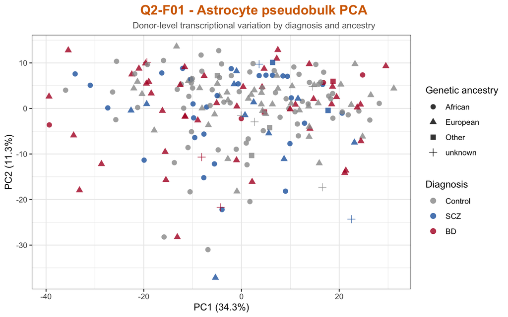

Q2-F01. Principal component analysis of variance-stabilized astrocyte pseudobulk profiles. Each point represents one donor. Colours indicate diagnosis and shapes indicate genetic ancestry

```r
pca_data$ancestry_model <- col_data[pca_data$name, "ancestry_model"]
pca_data$group <- factor(pca_data$group, levels = c("Control", "SCZ", "BD"))
percent_var <- round(100 * attr(pca_data, "percentVar"), 1)

p_pca <- ggplot(pca_data, aes(x = PC1, y = PC2, colour = group, shape = ancestry_model)) +
  geom_point(size = 2.5, alpha = 0.8) +
  scale_colour_manual(values = col_groups) +
  labs(
    title = "Q2-F01 - Astrocyte pseudobulk PCA",
    subtitle = "Donor-level transcriptional variation by diagnosis and ancestry",
    x = paste0("PC1 (", percent_var[1], "%)"),
    y = paste0("PC2 (", percent_var[2], "%)"),
    colour = "Diagnosis",
    shape = "Genetic ancestry") +
  theme_bw(base_size = 11) +
  theme(plot.title = element_text(hjust = 0.5, colour = col_main, face = "bold", size = 15),
    plot.subtitle = element_text(hjust = 0.5, colour = "grey40", size = 10),
    plot.title.position = "plot",
    legend.position = "right")

fig_dir <- here::here("04_FIGURES", "Q2_differential_expression")
dir.create(fig_dir, recursive = TRUE, showWarnings = FALSE)
ggsave(file.path(fig_dir, "Q2_F01_Astro_PCA.png"), plot = p_pca, width = 8, height = 5.5, dpi = 300)

p_pca
```

**NoteHow to read Figure Q2-F01**

Each point represents one donor-level astrocyte pseudobulk sample. Distances between points reflect differences in the most variable transcriptomic profiles. Colours identify diagnostic groups, while symbols represent genetic ancestry categories.

**TipInterpretation**

The two principal components explain 34.3% and 11.3% of the variation among astrocyte pseudobulk profiles.

Donors display noticeable transcriptional heterogeneity. African and European ancestry donors show considerable overlap across the first two components without an obvious separation.

Here, the PCA provides an exploratory overview of donor-level variation.

## 7.4 Dispersion estimates

```r
fig_dir <- here::here("04_FIGURES", "Q2_differential_expression")
dir.create(fig_dir, recursive = TRUE, showWarnings = FALSE)
disp_file <- file.path(fig_dir, "Q2_F02_Astro_Dispersion.png")

png(disp_file, width = 8, height = 5.5, units = "in", res = 300)
par(mar = c(5, 5, 5, 2), col.main = col_main, font.main = 2, cex.main = 1.05)

DESeq2::plotDispEsts(dds_astro)

title(main = "Q2-F02 - Dispersion estimates in astrocytes", line = 2)

dev.off()
```

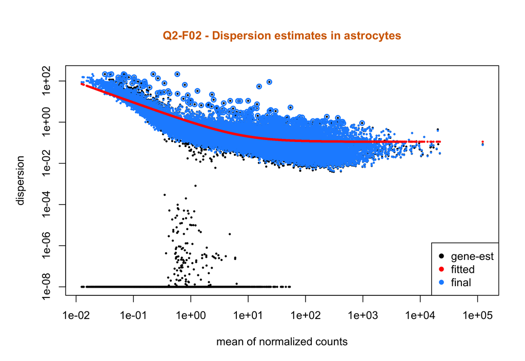

```r
knitr::include_graphics(disp_file)
```

**NoteHow to read Figure Q2-F02**

Each point represents a gene. The plot compares gene-wise dispersion estimates with the fitted mean–dispersion trend and the final estimates used by DESeq2.

**TipInterpretation**

The fitted trend relating the mean to the dispersion decreases as the normalized gene expression increases, eventually reaching a plateau at higher expression levels.

The final dispersion estimates generally follow this trend, although some genes exhibit greater than expected variability. Such deviations are consistent with biological heterogeneity specific to individual genes and are accounted for by the DESeq2 dispersion estimation procedure.

Overall, the graphical pattern does not suggest any clear failure in the dispersion fit. The presence of highly dispersed genes, as well as estimates near the lower bound, warrants further investigation supplementing the diagnostics performed at the sample and gene levels-before interpreting the results of the differential expression analysis.

# 8 Differential expression across eligible subclasses

## 8.1 Batch analysis

**NotePrinciple**

Following validation of the astrocyte pilot, the same differential expression workflow is applied to all eligible subclasses.

For each subclass, donor-level pseudobulk counts are extracted and genes with fewer than 10 total counts are removed. DESeq2 fits a negative binomial model adjusted for each variable. Three contrasts are extracted : SCZ vs Control, BD vs Control and SCZ vs BD.

Analysis is performed sequentially to limit memory usage.

```r
contrast_definitions <- list(
  SCZ_vs_Control = c("group", "SCZ", "Control"),
  BD_vs_Control  = c("group", "BD", "Control"),
  SCZ_vs_BD      = c("group", "SCZ", "BD"))

#Output directories
q2_dir <- here::here("03_RESULTS", "Q2_differential_expression")
deg_dir <- file.path(q2_dir, "DEG")
rank_dir <- file.path(q2_dir, "GSEA_rankings")
summary_dir <- file.path(q2_dir, "model_summaries")

for (dir_path in c(deg_dir, rank_dir, summary_dir)) {dir.create(dir_path, recursive = TRUE, showWarnings = FALSE)}

for (sc in eligible_subclasses) {

  summary_file <- file.path(summary_dir, paste0(sc, "_summary.csv"))
  result_files <- file.path(deg_dir, paste0(sc, "_", names(contrast_definitions), ".csv"))
  rank_files <- file.path(rank_dir, paste0(sc, "_", names(contrast_definitions), "_Wald_rank.csv"))
  sig_files <- file.path(deg_dir, paste0(sc, "_", names(contrast_definitions), "_FDR05.csv"))

  #Reuse results from completed analyses
  if (file.exists(summary_file) && all(file.exists(result_files)) && all(file.exists(rank_files)) && all(file.exists(sig_files))) {
    cat("Already completed:", sc, "\n")
    next}

  cat("Processing:", sc, "\n")

  #Donor metadata for the analyzed subclass
  d <- meta_q2[meta_q2$subclass == sc, , drop = FALSE]

  d$group <- factor(d$group, levels = c("Control", "SCZ", "BD"))
  d$sex <- droplevels(factor(d$sex))
  d$ancestry_model <- droplevels(factor(d$ancestry_model))

  rownames(d) <- d$column

  if (sc == "Astro") {
    #Reuse validated pilot
    res_list <- results_astro
    n_genes <- nrow(count_data)
  } else {
    y <- counts[, d$column, drop = FALSE] #Extract only the current subclass
    keep <- Matrix::rowSums(y) >= 10     #Minimum count filter
    mat <- as.matrix(y[keep, , drop = FALSE])
    storage.mode(mat) <- "integer"
    stopifnot(nrow(mat) > 0, identical(colnames(mat), rownames(d)))
    n_genes <- nrow(mat)

    #Fit DESeq2
    dds <- DESeq2::DESeqDataSetFromMatrix(countData = mat,colData = d[, c("age", "sex", "ancestry_model", "group")], design = design_formula)
    dds <- DESeq2::DESeq(dds, quiet = TRUE)

    #Extract three contrasts
    res_list <- lapply(contrast_definitions, function(definition) {DESeq2::results(dds, contrast = definition, alpha = 0.05)})}

  #Export complete results and GSEA rankings
  summary_rows <- list()
  for (cn in names(contrast_definitions)) {
    res <- res_list[[cn]]
    res_table <- data.frame(gene = rownames(res), as.data.frame(res), check.names = FALSE)
    #Complete results (with non-significant genes)
    write.csv(res_table, file.path(deg_dir, paste0(sc, "_", cn, ".csv")), row.names = FALSE)
    #Significant genes
    is_deg <- !is.na(res_table$padj) & res_table$padj < 0.05
    write.csv(res_table[is_deg, , drop = FALSE], file.path(deg_dir, paste0(sc, "_", cn, "_FDR05.csv")), row.names = FALSE)
    #Wald statistic for preranked GSEA
    rank_table <- res_table[is.finite(res_table$stat), c("gene", "stat"), drop = FALSE]
    rank_table <- rank_table[order(rank_table$stat, decreasing = TRUE), , drop = FALSE]
    write.csv(rank_table, file.path(rank_dir, paste0(sc, "_", cn, "_Wald_rank.csv")), row.names = FALSE)
    #Subclass × contrast summary
    summary_rows[[cn]] <- data.frame(
      Subclass = sc,
      Contrast = cn,
      Donors = nrow(d),
      Genes_retained = n_genes,
      Genes_tested = sum(!is.na(res$pvalue)),
      Genes_with_padj = sum(!is.na(res$padj)),
      DEG_FDR_0.05 = sum(is_deg),
      DEG_up = sum(is_deg & res$log2FoldChange > 0, na.rm = TRUE),
      DEG_down = sum(is_deg & res$log2FoldChange < 0, na.rm = TRUE))}

  sc_summary <- do.call(rbind, summary_rows)

  #Mark subclass completed only after writing all outputs
  write.csv(sc_summary, summary_file, row.names = FALSE)
  #Release intermediate objects before the next subclass
  if (sc != "Astro") {rm(y, keep, mat, dds)}
  rm(res_list, summary_rows, sc_summary, d)
  invisible(gc(verbose = FALSE))}
```

## 8.2 Differential expression summary

Results are summarized across all eligible subclasses and the three contrasts. The number of significant genes is reported alongside the number of tested genes and available adjusted p-values.

```r
summary_files <- file.path(summary_dir, paste0(eligible_subclasses, "_summary.csv"))
q2_summary <- do.call(rbind, lapply(summary_files, read.csv))
q2_summary$DEG_percent <- round(100 * q2_summary$DEG_FDR_0.05 / pmax(q2_summary$Genes_with_padj, 1), 2)
write.csv(q2_summary, file.path(q2_dir, "Q2_DESeq2_summary.csv"), row.names = FALSE)

#Display the strongest DEG counts
top_DEG_results <- head(q2_summary[order(q2_summary$DEG_FDR_0.05, decreasing = TRUE), ], 15)
knitr::kable(top_DEG_results, caption = "Top 15 subclass contrast combinations ranked by the number of significant genes")
```

Top 15 subclass contrast combinations ranked by the number of significant genes

|  | Subclass | Contrast | Donors | Genes_retained | Genes_tested | Genes_with_padj | DEG_FDR_0.05 | DEG_up | DEG_down | DEG_percent |
| --- | --- | --- | --- | --- | --- | --- | --- | --- | --- | --- |
| 4 | EN_L2_3_IT | SCZ_vs_Control | 206 | 34119 | 34097 | 25499 | 2455 | 1017 | 1438 | 9.63 |
| 31 | Endo | SCZ_vs_Control | 189 | 28635 | 28631 | 14753 | 1116 | 664 | 452 | 7.56 |
| 2 | Astro | BD_vs_Control | 215 | 33743 | 33711 | 22592 | 1103 | 893 | 210 | 4.88 |
| 13 | EN_L3_5_IT_3 | SCZ_vs_Control | 190 | 33941 | 33934 | 22091 | 964 | 512 | 452 | 4.36 |
| 49 | IN_SST | SCZ_vs_Control | 202 | 33719 | 33701 | 16058 | 836 | 404 | 432 | 5.21 |
| 52 | IN_VIP | SCZ_vs_Control | 209 | 33869 | 33859 | 21386 | 733 | 398 | 335 | 3.43 |
| 10 | EN_L3_5_IT_2 | SCZ_vs_Control | 197 | 33850 | 33839 | 20062 | 699 | 361 | 338 | 3.48 |
| 5 | EN_L2_3_IT | BD_vs_Control | 206 | 34119 | 34097 | 29466 | 685 | 591 | 94 | 2.32 |
| 7 | EN_L3_5_IT_1 | SCZ_vs_Control | 174 | 33362 | 33359 | 17191 | 538 | 248 | 290 | 3.13 |
| 62 | OPC | BD_vs_Control | 218 | 33423 | 33404 | 18507 | 517 | 438 | 79 | 2.79 |
| 65 | PC | BD_vs_Control | 160 | 26198 | 26198 | 6897 | 511 | 364 | 147 | 7.41 |
| 56 | Micro | BD_vs_Control | 196 | 30509 | 30496 | 13351 | 493 | 383 | 110 | 3.69 |
| 1 | Astro | SCZ_vs_Control | 215 | 33743 | 33711 | 21285 | 463 | 286 | 177 | 2.18 |
| 64 | PC | SCZ_vs_Control | 160 | 26198 | 26198 | 9945 | 385 | 247 | 138 | 3.87 |
| 14 | EN_L3_5_IT_3 | BD_vs_Control | 190 | 33941 | 33934 | 25381 | 336 | 282 | 54 | 1.32 |

```r
cat("Completed comparisons : ", nrow(q2_summary), "\n",
    "Subclasses analyzed : ", length(unique(q2_summary$Subclass)), "\n")
```

```
Completed comparisons :  69
 Subclasses analyzed :  23
```

**TipInterpretation**

The differential expression workflow was completed for **23 cell subclasses**, resulting in **69 subclass-specific diagnostic comparisons**.

The highest number of significant genes was detected in the **EN_L2_3_IT** subclass for the comparison between subjects with schizophrenia (SCZ) and controls (**2,455 differentially expressed genes [DEGs], FDR < 0.05**), followed by endothelial cells (Endo, 1,116 DEGs) and EN_L3_5_IT_3 neurons (964 DEGs).

For the comparison between subjects with bipolar disorder (BD) and controls, the highest number of significant genes was observed in **astrocytes (1,103 DEGs)**, followed by EN_L2_3_IT neurons (685 DEGs) and oligodendrocyte precursor cells (OPCs, 517 DEGs).

These results reveal different patterns of statistically relevant transcriptional alterations across both neuronal and non-neuronal populations. However, the number of differentially expressed genes (DEGs) depends on sample representation, expression levels, and statistical power. Therefore, it should not be interpreted as a direct measure of the magnitude of the biological effect.

## 8.3 Export of the complete DESeq2 table for Q3

The complete results are consolidated into a single CSV file following the shared project specification. Each row corresponds to one gene, one cell subclass and one diagnostic contrast.

The file contains results from 23 cell subclasses and 69 diagnostic comparisons, including SCZ versus Control, BD versus Control and SCZ versus BD.

All genes retained after the initial count prefilter are included, regardless of statistical significance. Missing statistics are preserved where DESeq2 could not calculate a value.

The original contrast names are converted to the common Q2–Q3 nomenclature (`SCZ_vs_CTRL`, `BD_vs_CTRL`, `SCZ_vs_BD`).

```
[1] "cell_type"      "contrast"       "gene"           "baseMean"
[5] "log2FoldChange" "lfcSE"          "stat"           "pvalue"
[9] "padj"
```

```
  cell_type    contrast   gene      stat
1     Astro SCZ_vs_CTRL TSPAN6 2.5520348
2     Astro SCZ_vs_CTRL   TNMD 1.1617296
3     Astro SCZ_vs_CTRL   DPM1 0.4513153
4     Astro SCZ_vs_CTRL  SCYL3 0.0217435
5     Astro SCZ_vs_CTRL  FIRRM 1.4518904
```

```
Total exported rows: 2218101
```

**TipInterpretation**

The complete DESeq2 outputs have been consolidated into **`de_results_all.csv`**, containing 2,218,101 gene-level rows across 23 cell subclasses and three diagnostic contrasts.

The export preserves effect estimates, Wald statistics and both raw and adjusted p-values, including non-significant genes. This provides the input required for downstream GSEA and ORA analyses in Q3, without repeating the differential expression workflow.

For preranked GSEA, genes without a finite Wald statistic must be excluded at the enrichment-analysis stage.

## 8.4 Distribution of significant genes across subclasses

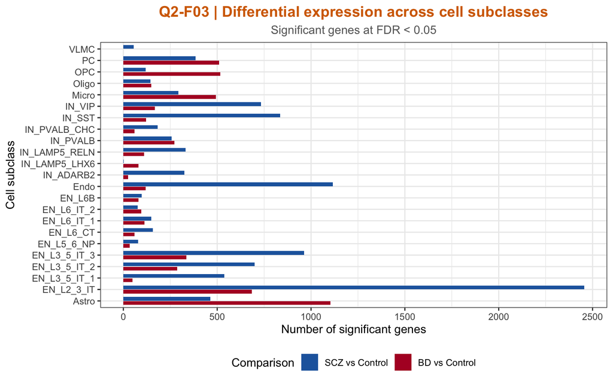

```r
plot_data <- q2_summary[q2_summary$Contrast %in% c("SCZ_vs_Control", "BD_vs_Control"),]

p_deg <- ggplot(plot_data, aes(x = Subclass, y = DEG_FDR_0.05, fill = Contrast)) +
  geom_col(position = position_dodge(width = 0.75), width = 0.65) +
  coord_flip() +
  scale_fill_manual(values = c(SCZ_vs_Control = "#2166ac", BD_vs_Control = "#b2182b"),
                    breaks = c("SCZ_vs_Control", "BD_vs_Control"),
                    labels = c(SCZ_vs_Control = "SCZ vs Control", BD_vs_Control = "BD vs Control")) +
  labs(title = "Q2-F03 | Differential expression across cell subclasses",
    subtitle = "Significant genes at FDR < 0.05",
    x = "Cell subclass",
    y = "Number of significant genes",
    fill = "Comparison") +
  theme_bw(base_size = 11) +
  theme(plot.title = element_text(hjust = 0.5, face = "bold", colour = col_main, size = 14), plot.subtitle = element_text(hjust = 0.5, colour = "grey40"), legend.position = "bottom")

ggsave(file.path(fig_dir, "Q2_F03_DEG_by_subclass.png"), plot = p_deg, width = 9, height = 9, dpi = 300)

p_deg
```

**NoteHow to read Figure Q2-F03**

Each pair of bars represents the number of genes meeting the FDR < 0.05 threshold within one cell subclass. Blue bars correspond to SCZ versus Controls and red bars to BD versus Controls. These counts reflect statistical discoveries rather than the transcriptional alterations.

**TipInterpretation**

The number of significant genes varies considerably across the 23 cell subclasses analyzed, with distinct profiles observed in schizophrenia (SCZ) and bipolar disorder (BD).

In SCZ, **EN_L2_3_IT neurons exhibit the most extensive transcriptional signature**, with 2,455 significant genes (1,017 upregulated and 1,438 downregulated). Endothelial cells also show a substantial number of significant genes (1,116), suggesting that the detectable alterations are not limited to neuronal populations.

In BD, **astrocytes show the highest number of significant genes (1,103)**, the majority of which are upregulated (893 upregulated versus 210 downregulated). Significant transcriptional alterations are also detected within neuronal populations, oligodendrocyte precursor cells, and microglia.

These observations suggest differences in the distribution of detectable transcriptional alterations between the two disorders. However, the profiles seemingly associated with the disease require gene-level comparisons and the consideration of potential confounding factors before biological specificity can be established.

# 9 Ancestry-restricted sensitivity analyses

## 9.1 Astrocyte sensitivity models

```r
sensitivity_specs <- list(SCZ_African = list(ancestry = "African", case = "SCZ"), BD_European = list( ancestry = "European", case = "BD"))

sens_dir <- file.path(q2_dir, "sensitivity")
dir.create(sens_dir, recursive = TRUE)

sens_summary <- list()

for (nm in names(sensitivity_specs)) {
  spec <- sensitivity_specs[[nm]]
  d_sens <- col_data[col_data$ancestry == spec$ancestry & col_data$group %in% c("Control", spec$case), , drop = FALSE]
  d_sens$group <- factor(as.character(d_sens$group), levels = c("Control", spec$case))
  d_sens$sex <- droplevels(factor(d_sens$sex))
  rownames(d_sens) <- d_sens$column
  mm <- model.matrix(~ age + sex + group, data = d_sens)

  stopifnot(min(table(d_sens$group)) >= 10, qr(mm)$rank == ncol(mm))

  y_sens <- counts[, d_sens$column, drop = FALSE]
  keep_sens <- Matrix::rowSums(y_sens) >= 10
  mat_sens <- as.matrix(y_sens[keep_sens, , drop = FALSE])
  storage.mode(mat_sens) <- "integer"

  dds_sens <- DESeq2::DESeqDataSetFromMatrix(countData = mat_sens, colData = d_sens[, c("age", "sex", "group")], design = ~ age + sex + group)
  dds_sens <- DESeq2::DESeq(dds_sens, quiet = TRUE)

  res_sens <- DESeq2::results(dds_sens, contrast = c("group", spec$case, "Control"), alpha = 0.05)

  write.csv(data.frame(gene = rownames(res_sens), as.data.frame(res_sens)), file.path(sens_dir, paste0(nm, "_results.csv")), row.names = FALSE)

  sens_summary[[nm]] <- data.frame(Comparison = nm, Controls = sum(d_sens$group == "Control"), Cases = sum(d_sens$group == spec$case), Genes_tested = sum(!is.na(res_sens$pvalue)), DEG_FDR_0.05 = sum(res_sens$padj < 0.05, na.rm = TRUE))

  rm(y_sens, mat_sens, dds_sens, res_sens)
  invisible(gc(verbose = FALSE))}

sens_summary <- do.call(rbind, sens_summary)
rownames(sens_summary) <- NULL
write.csv(sens_summary, file.path(sens_dir, "Astro_sensitivity_summary.csv"), row.names = FALSE)
```

```r
knitr::kable(sens_summary, caption = "Ancestry-restricted differential expression sensitivity analyses in astrocytes")
```

Ancestry-restricted differential expression sensitivity analyses in astrocytes

| Comparison | Controls | Cases | Genes_tested | DEG_FDR_0.05 |
| --- | --- | --- | --- | --- |
| SCZ_African | 68 | 29 | 33121 | 0 |
| BD_European | 42 | 44 | 32967 | 776 |

**TipInterpretation**

Sensitivity analyses stratified by ancestry revealed contrasting results between the two disorders.

For **schizophrenia (SCZ) versus controls among donors of African ancestry**, the analysis included 68 controls and 29 donors with SCZ. Although 33,121 genes were tested, **no gene reached an FDR threshold of < 0.05**, compared to 463 significant genes in the primary adjusted analysis.

For **bipolar disorder (BD) versus controls among donors of European ancestry**, 42 controls and 44 donors with BD were included. Out of 32,967 genes tested, **776 genes were identified as significant**, compared to 1,103 in the primary model.

The absence of significant genes in the ancestry-stratified analysis for SCZ raises questions regarding the robustness of the primary findings. However, this cannot be attributed solely to ancestry-related confounding, as restricting the sample also reduces statistical power and alters the donor population being analyzed.

The persistence of a substantial number of significant genes in the bipolar disorder analysis is encouraging. However, confirming individual transcriptional signals requires comparing effect sizes and gene-level concordance between the primary and restricted models.

Overall, these results highlight the significance of ancestry-related imbalance as a study limitation, particularly regarding the interpretation of transcriptional alterations associated with schizophrenia.

# 10 Age-threshold sensitivity analysis

**NotePrinciple**

The primary differential expression analysis includes donors aged 20 years or older. To assess the robustness of the results to this inclusion criterion, a sensitivity analysis is performed using a stricter minimum age of **24 years**, as proposed in the shared project guidelines.

The same pseudobulk filtering criteria, statistical model and three diagnostic contrasts are retained. Differential expression results are compared with the primary analysis using DEG counts, log2 fold-change correlations and direction concordance.

## 10.1 Cohort restriction and subclass eligibility

The age threshold is increased from 20 to 24 years without repeating pseudobulk aggregation. The minimum requirement of 20 nuclei per donor–subclass profile and at least 10 eligible donors per diagnostic group is reapplied.

```r
meta_age24 <- meta_q2[meta_q2$age >= 24, , drop = FALSE]

donor_counts_24 <- with(meta_age24, table(factor(subclass, levels = eligible_subclasses), factor(group, levels = c("Control", "SCZ", "BD"))))
eligible_24 <- rownames(donor_counts_24)[apply(donor_counts_24, 1, min) >= donors_min_per_group]

age24_cohort_summary <- data.frame(
  Criterion = c("Donors in primary cohort (age >= 20)", "Donors in sensitivity cohort (age >= 24)", "Donors excluded by the new threshold", "Eligible subclasses"),
  Value = c(length(unique(meta_q2$donor)), length(unique(meta_age24$donor)), length(unique(meta_q2$donor)) - length(unique(meta_age24$donor)), length(eligible_24)))

knitr::kable(age24_cohort_summary, caption = "Cohort and subclass eligibility after increasing the minimum age to 24 years")
```

Cohort and subclass eligibility after increasing the minimum age to 24 years

| Criterion | Value |
| --- | --- |
| Donors in primary cohort (age >= 20) | 224 |
| Donors in sensitivity cohort (age >= 24) | 208 |
| Donors excluded by the new threshold | 16 |
| Eligible subclasses | 23 |

```r
stopifnot(setequal(eligible_24, eligible_subclasses))
```

**TipInterpretation**

Increasing the minimum age threshold from 20 to 24 years reduced the cohort from **224 to 208 donors**, excluding 16 younger individuals.

All **23 cell subclasses remained eligible**, preserving the same level of cellular annotation as the primary analysis.

This allows the sensitivity analysis to evaluate the impact of the age inclusion threshold without removing entire cell subclasses. However, statistical model must be reassessed after the cohort restriction.

## 10.2 Model identifiability

The original DESeq2 design is retained, including age, sex, genetic ancestry and diagnosis. Model matrices are checked again because removing donors may affect the representation of covariate categories.

```r
design_24 <- do.call(rbind, lapply(eligible_24,
  function(sc) {
    d <- meta_age24[meta_age24$subclass == sc, , drop = FALSE]
    d$group <- factor(d$group, levels = c("Control", "SCZ", "BD"))
    d$sex <- droplevels(factor(d$sex))
    d$ancestry_model <- droplevels(factor(d$ancestry_model))

    mm <- model.matrix(design_formula, data = d)

    data.frame(Subclass = sc,
               Donors = nrow(d),
               Parameters = ncol(mm),
               Rank = qr(mm)$rank,
               Full_rank = qr(mm)$rank == ncol(mm))}))

knitr::kable(design_24, caption = "Model identifiability after restricting the cohort to donors aged 24 years or older")
```

Model identifiability after restricting the cohort to donors aged 24 years or older

| Subclass | Donors | Parameters | Rank | Full_rank |
| --- | --- | --- | --- | --- |
| Astro | 199 | 8 | 8 | TRUE |
| EN_L2_3_IT | 194 | 8 | 8 | TRUE |
| EN_L3_5_IT_1 | 166 | 8 | 8 | TRUE |
| EN_L3_5_IT_2 | 187 | 8 | 8 | TRUE |
| EN_L3_5_IT_3 | 179 | 8 | 8 | TRUE |
| EN_L5_6_NP | 140 | 8 | 8 | TRUE |
| EN_L6_CT | 146 | 8 | 8 | TRUE |
| EN_L6_IT_1 | 139 | 8 | 8 | TRUE |
| EN_L6_IT_2 | 99 | 8 | 8 | TRUE |
| EN_L6B | 127 | 8 | 8 | TRUE |
| Endo | 174 | 8 | 8 | TRUE |
| IN_ADARB2 | 161 | 8 | 8 | TRUE |
| IN_LAMP5_LHX6 | 147 | 8 | 8 | TRUE |
| IN_LAMP5_RELN | 176 | 8 | 8 | TRUE |
| IN_PVALB | 188 | 8 | 8 | TRUE |
| IN_PVALB_CHC | 161 | 8 | 8 | TRUE |
| IN_SST | 190 | 8 | 8 | TRUE |
| IN_VIP | 197 | 8 | 8 | TRUE |
| Micro | 182 | 8 | 8 | TRUE |
| Oligo | 204 | 8 | 8 | TRUE |
| OPC | 203 | 8 | 8 | TRUE |
| PC | 147 | 8 | 8 | TRUE |
| VLMC | 95 | 8 | 8 | TRUE |

```r
stopifnot(all(design_24$Full_rank))
```

**TipInterpretation**

All **23 eligible subclasses retained full-rank design matrices** after restricting the analysis to donors aged 24 years or older.

For each subclass, the model matrix contained eight parameters and had a rank of eight, indicating that the adjusted DESeq2 model remained identifiable despite the reduction in cohort size.

However, full-rank models do not guarantee balanced diagnostic groups or eliminate potential confounding, particularly regarding genetic ancestry.

## 10.3 Differential expression analysis at age >= 24

The DESeq2 workflow is repeated for the 23 eligible subclasses. All three contrasts are retained, and results are saved separately from the primary analysis to prevent overwriting.

```r
age24_dir <- file.path(q2_dir, "sensitivity", "age24")
dir.create(age24_dir, recursive = TRUE, showWarnings = FALSE)

for (sc in eligible_24) {
  out_file <- file.path(
    age24_dir,
    paste0(sc, "_age24.rds"))

  if (file.exists(out_file)) next

  d <- meta_age24[meta_age24$subclass == sc, , drop = FALSE]

  d$group <- factor(d$group, levels = c("Control", "SCZ", "BD"))
  d$sex <- droplevels(factor(d$sex))
  d$ancestry_model <- droplevels(factor(d$ancestry_model))

  rownames(d) <- d$column

  #Extract subclass-specific raw counts
  y <- counts[, d$column, drop = FALSE]

  #Apply the same gene filtering criterion
  keep <- Matrix::rowSums(y) >= 10
  mat <- as.matrix(y[keep, , drop = FALSE])

  storage.mode(mat) <- "integer"
  stopifnot(nrow(mat) > 0,identical(colnames(mat), rownames(d)))

  #Fit the same adjusted DESeq2 model
  dds <- DESeq2::DESeqDataSetFromMatrix(countData = mat, colData = d[, c("age", "sex", "ancestry_model", "group")], design = design_formula)
  dds <- DESeq2::DESeq(dds, quiet = TRUE)

  #Extract the three original contrasts
  res24 <- lapply(contrast_definitions, function(def) {as.data.frame(DESeq2::results(dds, contrast = def, alpha = 0.05))})

  saveRDS(list(donors = nrow(d), results = res24), out_file)

  rm(d, y, keep, mat, dds, res24)
  invisible(gc(verbose = FALSE))}
```

## 10.4 Comparison with the primary analysis

Results obtained with the two age thresholds are compared at the gene level.

Spearman correlations quantify the consistency of log2 fold changes across genes present in both analyses. Direction concordance is calculated among genes significant in the primary analysis and with finite effect estimates in both models.

```r
age24_summary <- list()

for (sc in eligible_24) {obj <- readRDS(file.path(age24_dir, paste0(sc, "_age24.rds")))

  for (cn in names(contrast_definitions)) {primary <- read.csv(file.path(deg_dir, paste0(sc, "_", cn, ".csv")),check.names = FALSE)
    res24 <- obj$results[[cn]]
    res24$gene <- rownames(res24)

    comparison <- merge(primary[, c("gene", "log2FoldChange", "padj")], res24[, c("gene", "log2FoldChange", "padj")], by = "gene", suffixes = c("_20", "_24"))

    valid <- is.finite(comparison$log2FoldChange_20) & is.finite(comparison$log2FoldChange_24)

    primary_deg <- valid & !is.na(comparison$padj_20) &comparison$padj_20 < 0.05

    lfc_correlation <- if (sum(valid) >= 3) {suppressWarnings(cor(comparison$log2FoldChange_20[valid], comparison$log2FoldChange_24[valid], method = "spearman"))
    } else {NA_real_}

    direction_concordance <- if (sum(primary_deg) > 0) {100 * mean(sign(comparison$log2FoldChange_20[primary_deg]) == sign(comparison$log2FoldChange_24[primary_deg]))
    } else {NA_real_}

    age24_summary[[paste(sc, cn, sep = "_")]] <- data.frame(
      Subclass = sc,
      Contrast = cn,
      Donors_24 = obj$donors,
      DEG_20 = sum(primary$padj < 0.05, na.rm = TRUE),
      DEG_24 = sum(res24$padj < 0.05, na.rm = TRUE),
      LFC_Spearman = lfc_correlation,
      Direction_concordance_pct = round(direction_concordance, 1))}}

age24_summary <- do.call(rbind, age24_summary)

rownames(age24_summary) <- NULL

stopifnot(nrow(age24_summary) == 69)

write.csv(age24_summary, file.path(age24_dir, "age24_comparison_summary.csv"), row.names = FALSE)

#Global summary by diagnostic contrast
age24_global <- aggregate(cbind(LFC_Spearman, Direction_concordance_pct) ~ Contrast, data = age24_summary, FUN = function(x) {if (all(is.na(x))) NA_real_ else median(x, na.rm = TRUE)}, na.action = na.pass)

knitr::kable(age24_global, digits = 3, caption = "Median effect-size correlation and direction concordance between age thresholds, by diagnostic contrast")
```

Median effect-size correlation and direction concordance between age thresholds, by diagnostic contrast

| Contrast | LFC_Spearman | Direction_concordance_pct |
| --- | --- | --- |
| BD_vs_Control | 0.976 | 100 |
| SCZ_vs_BD | 0.991 | 100 |
| SCZ_vs_Control | 0.994 | 100 |

```r
#Detailed results for the astrocyte pilot
knitr::kable(age24_summary[age24_summary$Subclass == "Astro", , drop = FALSE], digits = 3, caption = "Age-threshold sensitivity results in astrocytes.")
```

Age-threshold sensitivity results in astrocytes.

| Subclass | Contrast | Donors_24 | DEG_20 | DEG_24 | LFC_Spearman | Direction_concordance_pct |
| --- | --- | --- | --- | --- | --- | --- |
| Astro | SCZ_vs_Control | 199 | 463 | 564 | 0.986 | 100 |
| Astro | BD_vs_Control | 199 | 1103 | 1194 | 0.976 | 100 |
| Astro | SCZ_vs_BD | 199 | 5 | 6 | 0.989 | 100 |

**TipInterpretation**

Raising the minimum age threshold from 20 to 24 years reduced the cohort size from **224 to 208 donors**, while retaining all **23 eligible cell subclasses**.

Across the 69 comparisons specific to each subclass, variations in gene expression (expressed as the log2 ratio of abundances) showed **very high median Spearman correlations** between the initial models and those restricted by age: **0.9943 for the schizophrenia (SCZ) versus control comparison**, **0.9763 for the bipolar disorder (BD) versus control comparison**, and **0.9913 for the SCZ versus BD comparison**.

The median concordance in the direction of change-among genes that were initially significant and had finite effect estimates-reached **100% for all three contrasts**, indicating substantial consistency regarding the direction of the estimated transcriptional changes.

In astrocytes, the number of significant genes shifted from 463 to 564 for the SCZ versus control comparison, from 1,103 to 1,194 for the BD versus control comparison, and from 5 to 6 for the direct comparison between SCZ and BD.

Overall, these results suggest that the **estimated transcriptional effects are largely robust to the minimum age threshold** applied to the various cell subclasses analyzed. However, given the significant overlap between the two cohorts, this analysis does not constitute an independent validation. Furthermore, the stability observed with respect to the age criterion does not rule out the possibility of confounding factors, such as genetic ancestry or other unmeasured variables.

# 11 Conclusion

**NoteConclusion**

This notebook provided a donor-level pseudobulk differential expression workflow for SCZ and BD in the PsychAD cohort.

Starting from 224 selected donors and 27 annotated cell subclasses, eligibility filtering retained **4 042 donor subclass profiles across 23 subclasses**. Four poorly represented populations were excluded according to the predefined minimum nucleus and donor-count thresholds.

Differential expression was analyzed using DESeq2 with age, sex and genetic ancestry included as covariates. Three contrasts were investigated within each eligible subclass : SCZ versus Controls, BD versus Controls and SCZ versus BD, providing in total **69 subclass specific comparisons**.

In the astrocyte pilot, 463 genes were significantly associated with SCZ versus controls and 1 103 BD versus controls. Only 5 genes reached the required FDR in the direct SCZ vs BD comparison. Across the remaining subclasses, the number of significant genes varied, supporting further investigation of cell-subclass-dependent transcriptional signatures.

**Several limitations must be considered.** Genetic ancestry and age distributions differed substantially between diagnostic groups.

Sensitivity analyses provided further insight into the robustness of the results. Analyses stratified by ancestry revealed no significant genes for schizophrenia (SCZ) compared to controls among astrocyte donors of African ancestry, whereas 776 genes remained significant for bipolar disorder (BD) compared to controls among donors of European ancestry.

Conversely, increasing the minimum age threshold from 20 to 24 years showed highly consistent transcriptional effect estimates across the 23 eligible cell subclasses, with median Spearman correlations ranging from 0.9763 to 0.9943 and a median directional concordance of 100% among previously significant genes with comparable effect estimates.

These findings support the stability of differential expression estimates with respect to the age threshold, while highlighting ancestry-related genetic imbalance as a significant, unresolved limitation. A sensitivity analysis using a 17-year threshold could not be performed, as the corresponding younger donors were absent from the available pseudobulk dataset.

Furthermore, false discovery rate correction was applied within each subclass-contrast analysis, rather than globally across all 69 comparisons. DEG counts should therefore be interpreted descriptively, without treating them as directly comparable measures of biological impact.

The complete DESeq2 results (including non-significant and Wald statistics) were exported for downstream GSEA.

The next notebook `03_Q2_2_shared_specific_signature.qmd`, will investigate concordant and discordant expression changes, shared transcriptional signatures and disease-associated differences across cell subclasses.

# 12 References

[1] Fullard, J. F., et al. (2025). Population-scale cross-disorder atlas of the human prefrontal cortex at single-cell resolution. Scientific Data, 12(1), 954. https://doi.org/10.1038/s41597-025-04687-5

[2] Squair, J. W., et al. (2021). Confronting false discoveries in single-cell differential expression. Nature Communications, 12(1), 5692. https://doi.org/10.1038/s41467-021-25960-2

[3] Love, M. I., Huber, W., & Anders, S. (2014). Moderated estimation of fold change and dispersion for RNA-seq data with DESeq2. Genome Biology, 15(12), 550. https://doi.org/10.1186/s13059-014-0550-8

[4] Love, M. I., et al. (Bioconductor). Analyzing RNA-seq data with DESeq2 (package vignette). https://bioconductor.org/packages/release/bioc/vignettes/DESeq2/inst/doc/DESeq2.html